# Fruit Firmness Analysis

Jimmy Larson

10/29/2020

## Introduction

This is a file that describes the process for analyzing fruit firmness for a preharvest drop study conducted from Aug.-Oct. 2020 on Red Delicious apples. 12 total fruit from the outside 2 trees per plot these fruit had their internal ethylene concentrations and firmness measured, juice from each apple in a treatment by rep combination was collected and had their brix measured using a refractometer. Two firmness measurements were taken on either side of the apple using a digital penetrometer:

- August 28
- September 1
- September 8
- September 14
- September 21
- September 29
- October 12

## Average Firmness

An average value of the two firmness measurements was first calculated…

```r
firmAug28 %>%
  mutate(firm = ((firm.1 + firm.2)/2)) %>%
  select(row, treatment, rep, fruit, firm)-> firmAug28
firmSep1 %>%
  mutate(firm = ((firm.1 + firm.2)/2)) %>%
  select(row, treatment, rep, fruit, firm) -> firmSep1
firmSep8 %>%
  mutate(firm = ((firm.1 + firm.2)/2)) %>%
  select(row, treatment, rep, fruit, firm) -> firmSep8
firmSep14 %>%
  mutate(firm = ((firm.1 + firm.2)/2)) %>%
  select(row, treatment, rep, fruit, firm) -> firmSep14
firmSep21 %>%
  mutate(firm = ((firm.1 + firm.2)/2)) %>%
  select(row, treatment, rep, fruit, firm)-> firmSep21
firmSep29 %>%
  mutate(firm = ((firm.1 + firm.2)/2)) %>%
  select(row, treatment, rep, fruit, firm)-> firmSep29
firmOct12 %>%
  mutate(firm = ((firm.1 + firm.2)/2)) %>%
  select(row, treatment, rep, fruit, firm)-> firmOct12
```

## Join Data

```r
firmAug28 %>%
  rename(firmAug28 = firm) %>%
  left_join(firmSep1) %>%
  rename(firmSep1 = firm) %>%
  left_join(firmSep8) %>%
  rename(firmSep8 = firm) %>%
  left_join(firmSep14) %>%
  rename(firmSep14 = firm) %>%
  left_join(firmSep21) %>%
  rename(firmSep21 = firm) %>%
  left_join(firmSep29) %>%
  rename(firmSep29 = firm) %>%
  left_join(firmOct12) %>%
  rename(firmOct12 = firm) -> firmness
```

## Explore Data

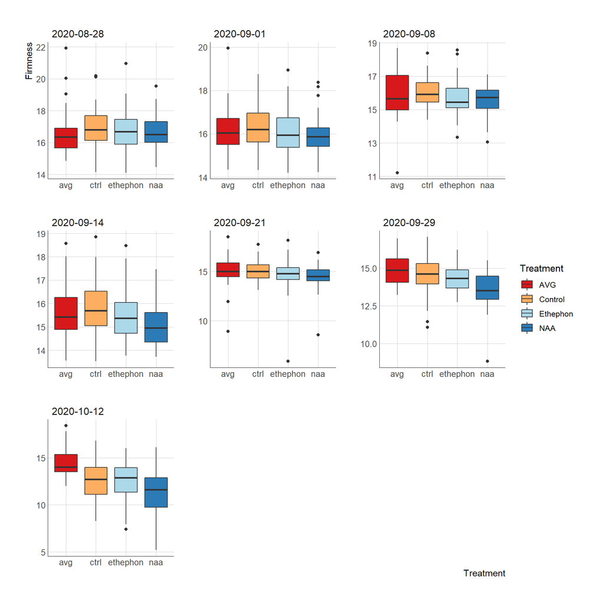

## ANOVA Assumptions

### ANOVA Model

```r
firmAug28.aov <- aov(firmAug28 ~ treatment, data = firmness)
Aug28Model <- data.frame(fit = fitted(firmAug28.aov),
                         res = resid(firmAug28.aov))
```

### Normality Check

```r
firmAug28.resid <- residuals(object = firmAug28.aov)
shapiro.test(x = firmAug28.resid)
```

### Homogeneity of Variance Check

```r
leveneTest(firmAug28 ~ treatment, data = firmness)
```

### **Aug. 28**

Shaprio-Wilkes test was significant, but levene’s test was not…

```
##
##  Shapiro-Wilk normality test
##
## data:  firmAug28.resid
## W = 0.95727, p-value = 1.497e-06
```

```
## Levene's Test for Homogeneity of Variance (center = median)
##        Df F value Pr(>F)
## group   3  1.0961 0.3515
##       236
```

### **Sep. 1**

Shaprio-Wilkes test was significant, but levene’s test was not…

```
##
##  Shapiro-Wilk normality test
##
## data:  firmSep1.resid
## W = 0.98186, p-value = 0.003767
```

```
## Levene's Test for Homogeneity of Variance (center = median)
##        Df F value Pr(>F)
## group   3  1.0545 0.3692
##       235
```

### **Sep. 8**

Both tests were significant…

```
##
##  Shapiro-Wilk normality test
##
## data:  firmSep8.resid
## W = 0.98032, p-value = 0.002104
```

```
## Levene's Test for Homogeneity of Variance (center = median)
##        Df F value   Pr(>F)
## group   3   4.539 0.004097 **
##       235
## ---
## Signif. codes:  0 '***' 0.001 '**' 0.01 '*' 0.05 '.' 0.1 ' ' 1
```

### **Sep. 14**

Shaprio-Wilkes test was significant, but levene’s test was not…

```
##
##  Shapiro-Wilk normality test
##
## data:  firmSep14.resid
## W = 0.97572, p-value = 0.0003915
```

```
## Levene's Test for Homogeneity of Variance (center = median)
##        Df F value Pr(>F)
## group   3  0.8026 0.4935
##       236
```

### **Sep. 21**

Shaprio-Wilkes test was significant, but levene’s test was not…

```
##
##  Shapiro-Wilk normality test
##
## data:  firmSep21.resid
## W = 0.84728, p-value = 1.388e-14
```

```
## Levene's Test for Homogeneity of Variance (center = median)
##        Df F value Pr(>F)
## group   3  0.7925 0.4992
##       234
```

### **Sep. 29**

Shaprio-Wilkes test was significant, but levene’s test was not…

```
##
##  Shapiro-Wilk normality test
##
## data:  firmSep29.resid
## W = 0.97537, p-value = 0.0004248
```

```
## Levene's Test for Homogeneity of Variance (center = median)
##        Df F value Pr(>F)
## group   3  1.1523 0.3288
##       230
```

### **Oct. 12**

Levene’s test was significant, but shapiro-wilkes test was not…

```
##
##  Shapiro-Wilk normality test
##
## data:  firmOct12.resid
## W = 0.99214, p-value = 0.2485
```

```
## Levene's Test for Homogeneity of Variance (center = median)
##        Df F value  Pr(>F)
## group   3  3.6435 0.01346 *
##       229
## ---
## Signif. codes:  0 '***' 0.001 '**' 0.01 '*' 0.05 '.' 0.1 ' ' 1
```

## Treatment Separation

### **Aug. 28**

```
##
##  Kruskal-Wallis rank sum test
##
## data:  firmAug28 by treatment
## Kruskal-Wallis chi-squared = 6.9745, df = 3, p-value = 0.07272
```

```
##
##  Pairwise comparisons using Wilcoxon rank sum test
##
## data:  firmness$firmAug28 and firmness$treatment
##
##          avg   ctrl  ethephon
## ctrl     0.079 -     -
## ethephon 0.234 0.457 -
## naa      0.234 0.298 0.846
##
## P value adjustment method: BH
```

### **Sep. 1**

```
##
##  Kruskal-Wallis rank sum test
##
## data:  firmSep1 by treatment
## Kruskal-Wallis chi-squared = 6.3214, df = 3, p-value = 0.09698
```

```
##
##  Pairwise comparisons using Wilcoxon rank sum test
##
## data:  firmness$firmSep1 and firmness$treatment
##
##          avg   ctrl  ethephon
## ctrl     0.427 -     -
## ethephon 0.633 0.325 -
## naa      0.325 0.067 0.427
##
## P value adjustment method: BH
```

### **Sep. 8**

```
##
##  Kruskal-Wallis rank sum test
##
## data:  firmSep8 by treatment
## Kruskal-Wallis chi-squared = 5.5989, df = 3, p-value = 0.1328
```

```
##
##  Pairwise comparisons using Wilcoxon rank sum test
##
## data:  firmness$firmSep8 and firmness$treatment
##
##          avg  ctrl ethephon
## ctrl     0.85 -    -
## ethephon 0.36 0.16 -
## naa      0.36 0.16 0.85
##
## P value adjustment method: BH
```

### **Sep. 14**

```
##
##  Kruskal-Wallis rank sum test
##
## data:  firmSep14 by treatment
## Kruskal-Wallis chi-squared = 17.307, df = 3, p-value = 0.000611
```

```
##
##  Pairwise comparisons using Wilcoxon rank sum test
##
## data:  firmness$firmSep14 and firmness$treatment
##
##          avg     ctrl    ethephon
## ctrl     0.29399 -       -
## ethephon 0.59967 0.13133 -
## naa      0.01012 0.00054 0.02932
##
## P value adjustment method: BH
```

### **Sep. 21**

```
##
##  Kruskal-Wallis rank sum test
##
## data:  firmSep21 by treatment
## Kruskal-Wallis chi-squared = 13.068, df = 3, p-value = 0.004492
```

```
##
##  Pairwise comparisons using Wilcoxon rank sum test
##
## data:  firmness$firmSep21 and firmness$treatment
##
##          avg   ctrl  ethephon
## ctrl     0.648 -     -
## ethephon 0.099 0.134 -
## naa      0.011 0.014 0.293
##
## P value adjustment method: BH
```

### **Sep. 29**

```
##
##  Kruskal-Wallis rank sum test
##
## data:  firmSep29 by treatment
## Kruskal-Wallis chi-squared = 37.783, df = 3, p-value = 3.141e-08
```

```
##
##  Pairwise comparisons using Wilcoxon rank sum test
##
## data:  firmness$firmSep29 and firmness$treatment
##
##          avg     ctrl    ethephon
## ctrl     0.12128 -       -
## ethephon 0.00586 0.30398 -
## naa      2.9e-08 0.00022 0.00046
##
## P value adjustment method: BH
```

### **Oct. 12**

```
##
##  Kruskal-Wallis rank sum test
##
## data:  firmOct12 by treatment
## Kruskal-Wallis chi-squared = 64.315, df = 3, p-value = 7.029e-14
```

```
##
##  Pairwise comparisons using Wilcoxon rank sum test
##
## data:  firmness$firmOct12 and firmness$treatment
##
##          avg     ctrl   ethephon
## ctrl     1.1e-06 -      -
## ethephon 8.0e-07 0.9912 -
## naa      3.8e-13 0.0022 0.0022
##
## P value adjustment method: BH
```

## Figure

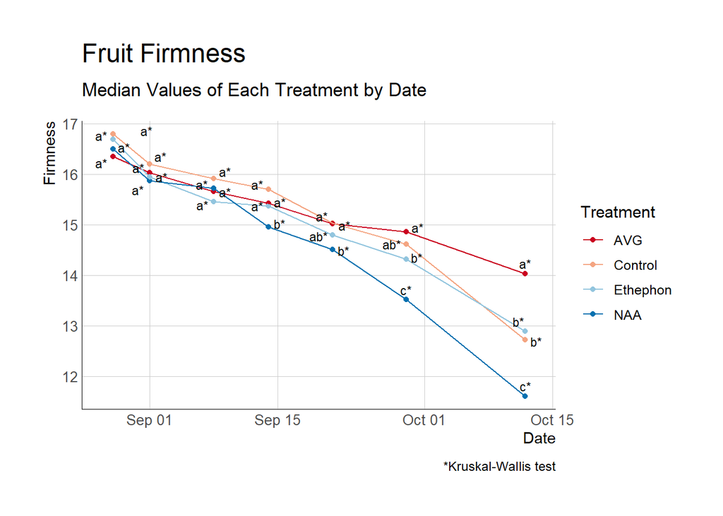